# ISL - Chapter 3 Exercises

Momoko Price

18/04/2020

##### Question 8

This question involves the use of simple linear regression on the Auto data set. First, use the lm() function to perform a simple linear regression with mpg as the response and horsepower as the predictor. Use the summary() function to print the results. Comment on the output, including the following points:

*Is there a relationship between the predictor and the response?*  
*How strong is the relationship between the predictor and the response?*  
*Is the relationship between the predictor and the response positive or negative?*  
*What is the predicted mpg associated with a horsepower of 98? What are the associated 95 % confidence and prediction intervals?*

```
##
## Call:
## lm(formula = mpg ~ horsepower, data = data)
##
## Residuals:
##      Min       1Q   Median       3Q      Max
## -13.3506  -6.0044  -0.3908   4.9519  22.9816
##
## Coefficients:
##             Estimate Std. Error t value Pr(>|t|)
## (Intercept) 17.80761    0.71129  25.036   <2e-16 ***
## horsepower   0.11080    0.01195   9.273   <2e-16 ***
## ---
## Signif. codes:  0 '***' 0.001 '**' 0.01 '*' 0.05 '.' 0.1 ' ' 1
##
## Residual standard error: 7.101 on 395 degrees of freedom
## Multiple R-squared:  0.1788, Adjusted R-squared:  0.1767
## F-statistic: 85.99 on 1 and 395 DF,  p-value: < 2.2e-16
```

**Answer:** *Yes, there is a relationship between horsepower and mpg. It’s a positive relationship (coefficient is positive), but not very strong (value is only 0.11). Moreover the R-squared value is only 0.17, which means that the relationship only accounts for a very small amount of the variation in the response.*

Next, plot the response and the predictor. Use the abline() function to display the least squares regression line.

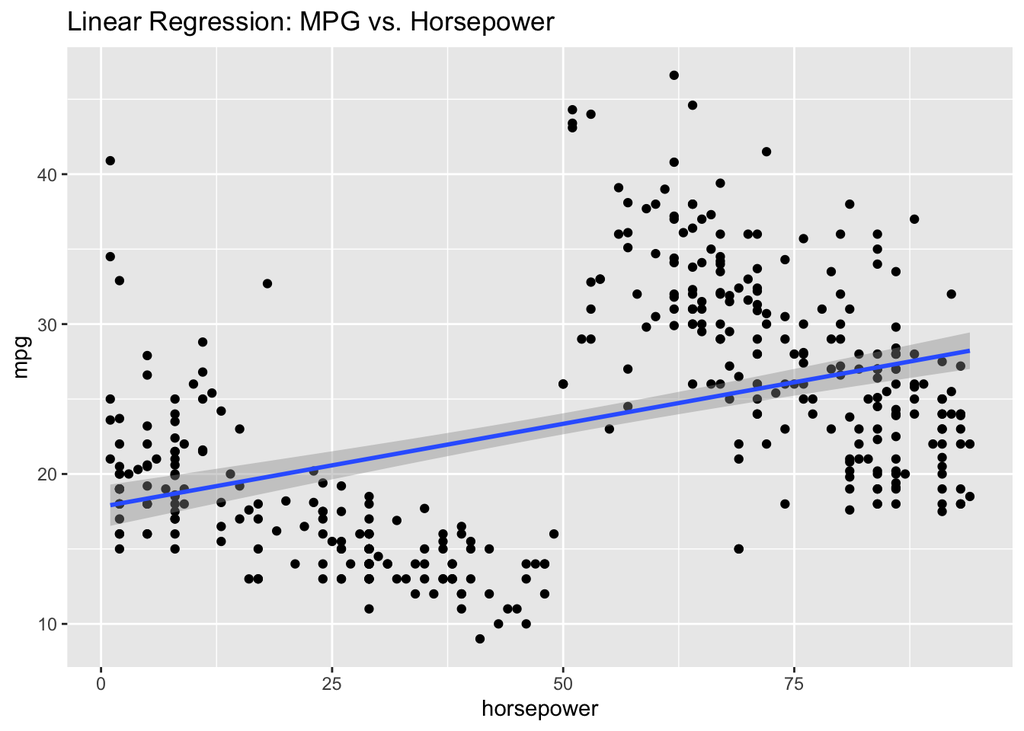

Next, use the plot() function to produce diagnostic plots of the least squares regression fit. Comment on any problems you see with the fit.

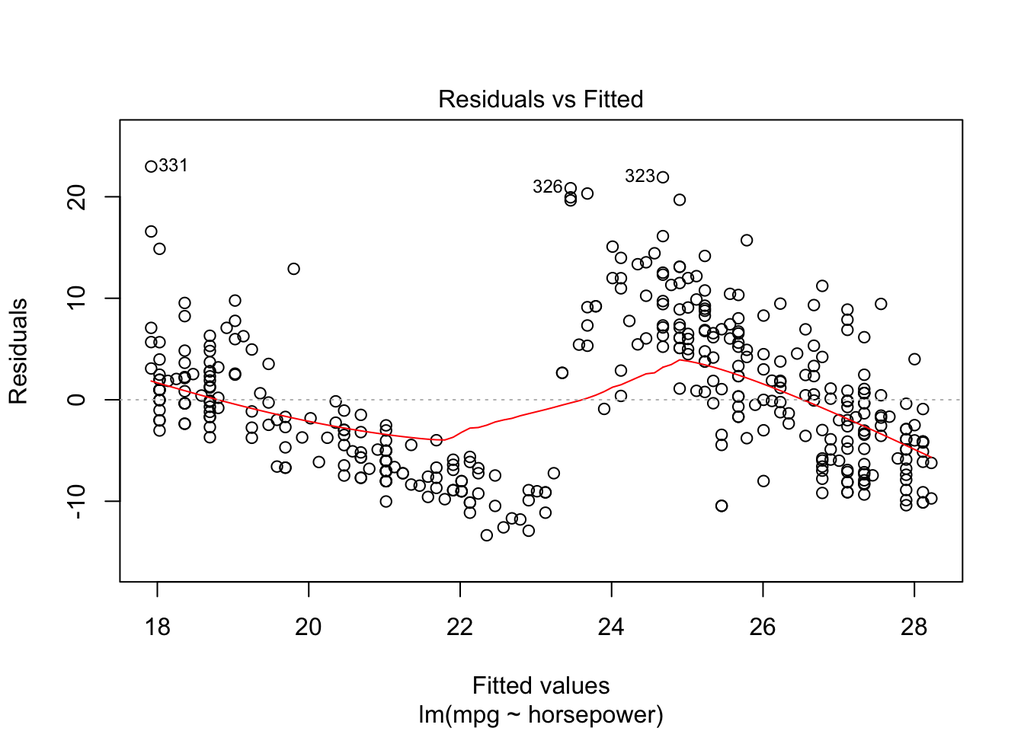

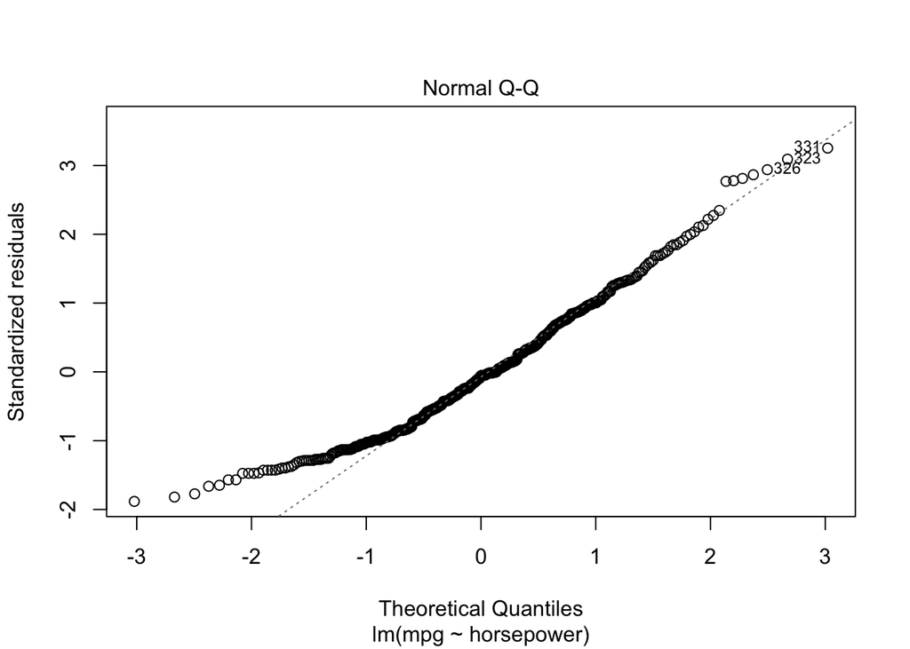

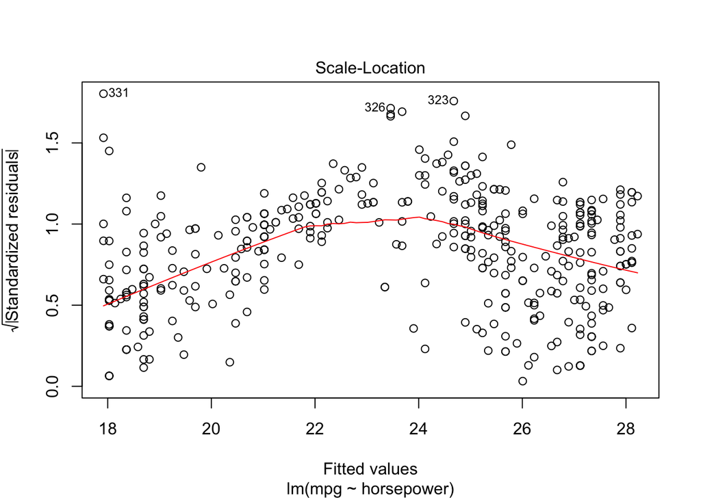

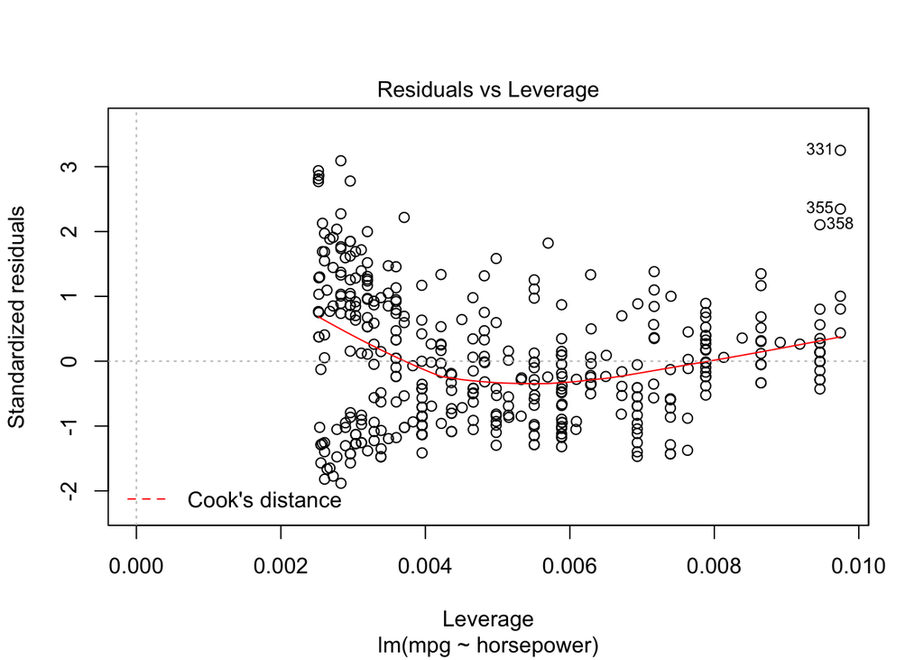

**Answer:** *There appears to be some non-random variability in these diagnostic plots. First, they cluster in 2 groups, which indicates some kind of correlation with another predictor. Second, the left tail of the distribution of residuals appears to be much steeper than the right. Third, the scale-location plot shows heteroscedasticity of the data. But there do not appear to be any clear high-leverage outliers.*

Last, calculate the predicted mpg associated with a horsepower of 98. What are the associated 95 % confidence and prediction intervals?

```r
# confidence interval
predict(lm.fit1, data.frame(horsepower = c(98)), interval = "confidence")
```

```
##        fit      lwr      upr
## 1 28.66647 27.36905 29.96389
```

```r
# prediction interval
predict(lm.fit1, data.frame(horsepower = c(98)), interval = "prediction")
```

```
##        fit     lwr      upr
## 1 28.66647 14.6462 42.68674
```

**Answer**: *The predicted MPG for a horsepower of 98 is 28.6, but the actual value could range anywhere between 14.6 and 42.69.*